##### Ver. 0.1, tw.steven@gmail.com

# Playing Algebra 2 with Python

Most important thing is manipulated it and and have fun!

(A much solid alternate of learning algebra: https://www.khanacademy.org/math/algebra2)

What you will learn:

1. Quadratic Functions
2. Polynominals
3. Rational Exponents and Radical Functions
4. Exponential and Logarithmic Functions
5. Rational Functions
6. Combination and Binominal Expansions
7. Sequence and Series
8. Circle,Ellipse,Parabola and Hyperbola
9. Trigonometric Functions
10. Trigonometric Graphs

Algebra talks about relationships. The relationship between input and output. The relationship between number and geometry. With the knowledge of Algebra, we are ready to understand Caculus. So, Algebra is in the center of Number, Geometry and Caculus.

From 15th century, Renaissance brings early Algebra from Arab area to Europe. After 200 years, the modern Algebra suddenly developed very quick in Europe and then followed by Science Revoultion and Industrial Revolution. So, Algebra is one of the key factors for Modernization.

Since it's the foundation of modern world, you can't avoid Algebra in your life. Best strategy is to learn it as early as possible. You come, you see, and then, Let's conquer it!

By the way, everythings converged to one simple beautiful formula: $e^{i\pi} + 1 = 0$. You will know how crazy it is after you learned Algebra.

### Ch1. Quadratic Functions and Factoring

#### What is a "Function"?

If you have an input x and an output y, then we may say y is function of x. And write as $ y = 𝑓(x) $

#### Quadratic Functions: 二次函數

Quadratic means "四邊形"。命名時可能是要算四邊形面積使用，但是實際上只有二次方。

(三次函數：Cubic Function, 四次函數：Quartic Function.)

Constant Function: $y = a$

Linear Function: $ y = ax $

Quadratic Function: $y = a x^2 + b x + c$ , where a is not 0.

Cubic Function: $y = a x^3 + b x^2 + c x + d$ , where a is not 0.

Quartic Function: $y = a x^4 + b x^3 + c x^2 + d x + e$ , where a is not 0.

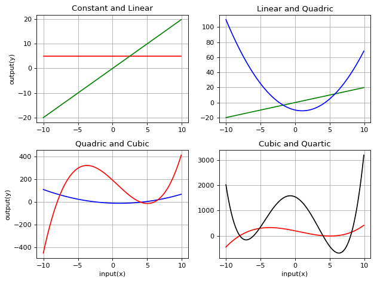

```python
################################################################################
# Let's see the functions in XY plane
# Author: stevenlee, tw.steven@gmail.com
# Date: 2017.05.16
################################################################################
# Import necessary modules:
# Numpy is for fundamental science computing. http://www.numpy.org/
# Matplotlib is for generating figures. https://matplotlib.org/
import numpy as np
import matplotlib.pyplot as plt

# Prepare the data x = [-10 -9.9 -9.8 ... -0.1 0, 0.1 ... 9.8 9.9]
x = np.arange(-10., 10., 0.1) # ask np to generate an array from -10 to 10, with step 0.1 (start, stop, step)

# Prepare different output data
y_constant = 0*x + 5                          # horizontal line y = 5
y_linear = 2*x                                # y = 2x
y_quadric = (x**2) - 2*x - 10.                # y = x^2 - 2x - 10
y_cubic = (x-4)*(x+8)*(x-6)                   # a cubic function with root at 4,6,-8
y_quartic = (x-4)*(x+8)*(x-8)*(x+6)           # a quartic function with root at 4,-8,8,-6


# Plot to figure
plt.figure(figsize=(8, 6), dpi=80)
plt.subplot(221)                              # A plot with 2x2 subplots, now plot the first
plt.title('Constant and Linear')              # Title of 1st subplot
plt.plot(x, y_constant,'r',x, y_linear, 'g')  # Plota red line and green line
plt.grid(True)                                # Turn on the grid
plt.ylabel('output(y)')                       # Y Label

plt.subplot(222)
plt.title('Linear and Quadric')
plt.plot(x, y_linear,'g',x, y_quadric, 'b')
plt.grid(True)

plt.subplot(223)
plt.title('Quadric and Cubic')
plt.plot(x, y_quadric,'b',x, y_cubic, 'r')
plt.grid(True)
plt.xlabel('input(x)')
plt.ylabel('output(y)')

plt.subplot(224)
plt.title('Cubic and Quartic')
plt.plot(x, y_cubic,'r',x, y_quartic, 'k')
plt.grid(True)
plt.xlabel('input(x)')

plt.tight_layout()                          # Tight the layout
plt.show()                                  # Show the plot
```

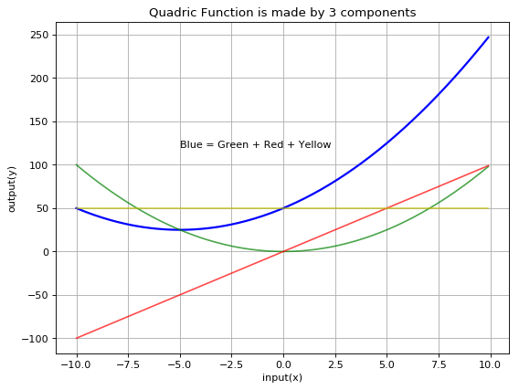

```python
################################################################################
# Let's see Quadric function's components
# Author: stevenlee, tw.steven@gmail.com
# Date: 2017.05.16
################################################################################
# Import necessary modules:
import numpy as np
import matplotlib.pyplot as plt

# Prepare the data
x = np.arange(-10., 10., 0.1) # ask np to generate an array from -10 to 10, with step 0.1 (start, stop, step)

# Polynominal Functions : Notice that a value times an array is an array
y0 = [50 for i in x]            # Same as y0 = 0*x + 50
y1 = 10*x
y2 = (x**2)
y_quardric = y2 + y1 + y0

# Plot to figure
plt.figure(figsize=(8, 6), dpi=80)
plt.title('Quadric Function is made by 3 components')
plt.plot(x, y_quardric, 'b',linewidth=2.0)
plt.plot(x, y2,'g', x, y1, 'r', x, y0, 'y', alpha=0.7)
plt.text(-5,120,'Blue = Green + Red + Yellow')
plt.xlabel('input(x)')
plt.ylabel('output(y)')
plt.grid(True)
plt.show()
```

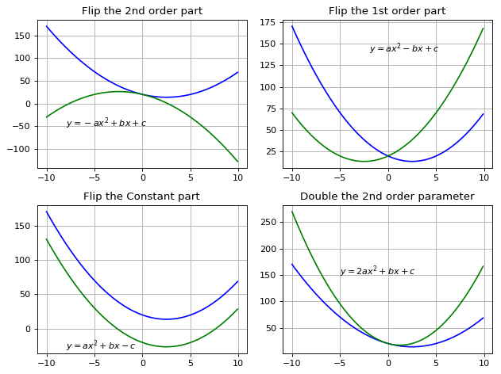

```python
################################################################################
# Let's see Quadric function's parameters
# Author: stevenlee, tw.steven@gmail.com
# Date: 2017.05.16
################################################################################
# Import necessary modules:
import numpy as np
import matplotlib.pyplot as plt

# Prepare the data
x = np.arange(-10., 10., 0.1) # ask np to generate an array from -10 to 10, with step 0.1 (start, stop, step)

# Polynomial Functions
y0 = 0*x + 20
y1 = -5*x
y2 = (x**2)
y_q1 = y2 + y1 + y0
y_q2 = -y2 + y1 + y0
y_q3 = y2 - y1 + y0
y_q4 = y2 + y1 - y0
y_q5 = 2*y2 + y1 + y0


# Plot to figure
plt.figure(figsize=(8, 6), dpi=80)
plt.subplot(221)
plt.title('Flip the 2nd order part')
plt.plot(x, y_q1, 'b',x, y_q2, 'g')
plt.text(-8,-50,'$y = -ax^2 + bx + c$') # Show text started at (x,y)
plt.grid(True)

plt.subplot(222)
plt.title('Flip the 1st order part')
plt.plot(x, y_q1, 'b',x, y_q3, 'g')
plt.text(-2,140,'$y = ax^2 - bx + c$')
plt.grid(True)

plt.subplot(223)
plt.title('Flip the Constant part')
plt.plot(x, y_q1, 'b',x, y_q4, 'g')
plt.text(-8,-30,'$y = ax^2 + bx - c$')
plt.grid(True)

plt.subplot(224)
plt.title('Double the 2nd order parameter')
plt.plot(x, y_q1, 'b',x, y_q5, 'g')
plt.text(-5,150,'$y = 2ax^2 + bx +c$')
plt.grid(True)

# plt.xlabel('input(x)')
# plt.ylabel('output(y)')
plt.tight_layout()
plt.show()
```

#### Vertex Form

```
If we know the vertex is (h,k), we may write:
```

$$y = a(x-h)^2 + k$$

```
The vertex is (h,k), the axis of symmetry is: x = h
```

#### Intercept Form

```
If we know interception points (a,0) and (b,0), we may write:
```

$$y = c(x-a)(x-b)$$

#### Factoring:

```
Factoring is to find intercept form. (x-k) is a factor.
```

$$ y = (x+a)(x+b) $$$$ y = x^2 + (a+b)x + ab $$

For example $ y = x^2 + 7x + 12 = (x+3)(x+4)$

##### Practice:

$x^2 + 4x + 4 = (x+2)^2$

$x^2 - 4x + 4 =(x-2)^2$

##### Hint:

$ a^2 - b^2 = (a+b)(a-b) $

$ a^2 + 2ab + b^2 = (a+b)^2 $

$ a^2 - 2ab + b^2 = (a-b)^2 $

#### Question: We always have vertex form for an $y = ax^2+bx+c$ equation? Why?

#### Question: We always have intercept form for an $y = ax^2+bx+c$ equation? Why?

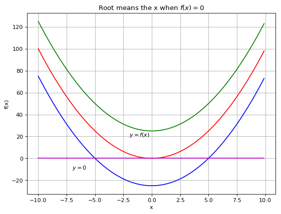

```python
################################################################################
# Let's see Quadric function's root
# Author: stevenlee, tw.steven@gmail.com
# Date: 2017.05.16
################################################################################
import numpy as np
import matplotlib.pyplot as plt

# Prepare the data
x = np.arange(-10., 10., 0.1) # ask np to generate an array from -10 to 10, with step 0.1 (start, stop, step)

y_zero = 0*x
y_q1 = (x-5)*(x+5)
y_q2 = (x-5)*(x+5) + 50
y_q3 = (x**2)

# Plot to figure
plt.figure(figsize=(8, 6), dpi=80)
plt.title('Root means the x when $f(x)=0$')
plt.plot(x, y_q1, 'b',x, y_q2, 'g',x, y_q3, 'r')
plt.plot(x, y_zero,'m')
plt.text(-2,20,'$y = f(x)$')
plt.text(-7,-10,'$y = 0$')
plt.xlabel('x')
plt.ylabel('f(x)')
plt.grid(True)
plt.show()
```

#### 1.8 Use the Quadratic Formula

Let a,b,c are real number, such that a≠0. The quadratic function is $y = ax^2 + bx + c $

To solve the function, we let y = 0, that is $ax^2 + bx + c = 0 $

The we may have $ x = \frac{-b ± \sqrt{b^2-4ac} }{2a}$

Here, we say D, the "Discriminant" for quadratic function, is $b^2-4ac$

- If D > 0 : Two real root
- If D = 0 : Same root
- If D < 0 : No real root

##### Question: What does it means "No real root"? Considering the imaginary part, where is the root exactly be?

##### Addition Material: What "No real root" really means...

We already have a quadratic function $y = ax^2 + bx + c$

Now we rewrite it as: $y = aw^2 + bw + c$, where $w = x + jz$

$$y = a(x + jz)^2 + b(x + jz) + c = a(x^2 - z^2 +2jxz) + b(x + jz) + c$$$$y = ax^2 + bx + (c-az^2) + j(2xy+bz)$$

Good! We know that z = 0 is just a special case. If z = 0, $y = ax^2 + bx + c$ .

Let's check an example: $a = 1, b = 0, c = 4$

As $(b^2-4ac) < 0 \to $ There is no "Real Root"

Let's play with complex number:

$y = (x+jz)^2 + 4$

$y = x^2 - z^2 + 4 + jxz$

Root means y = 0, that is 0 in real part, and 0 in imaginary part (y = 0 + 0j)

Imaginary part: $xz = 0$

Real part: $(x+jz)^2 + 4 = x^2 - z^2 + 4 = 0$

We may infer:

1. x = 0 or z = 0 (Come from xz=0)
2. When x = 0, then z = ±2; When z = 0, then x = 2j, which is not "real", so z≠0

So, we have roots: 2j and -2j Let's see what happened by figure:

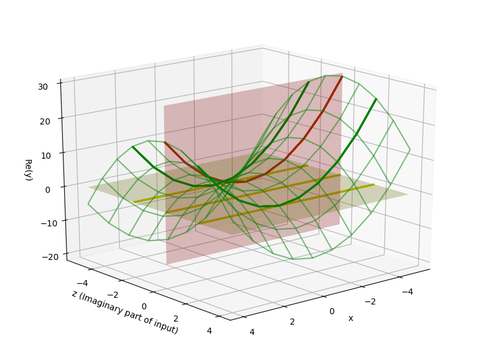

```python
################################################################################
# Let's see Quadric function when discriminant < 0,  for example, y = x^2 + 4
# Author: stevenlee, tw.steven@gmail.com
# Date: 2017.05.16
################################################################################
import numpy as np
import matplotlib.pyplot as plt
from mpl_toolkits.mplot3d import axes3d # package that support 3D plot

# Prepare the data
x = []                                  # An empty array
z = []                                  # An empty array
l = np.arange(-5., 5., 1)               # l = [-5,-4,-3,-2,-1,0,1,2,3,4]
length = len(l)                         # length = 10
for i in range(length):
    x.append(l)                         # x is a list with 100 elements

x = np.asarray(x)                       # x is an 100x1 array
x.reshape((length,length))              # x is an 10x10 array
z = np.transpose(x)                     # z is transpose(x)

# Assume x is real value, imaginary value z is zero
y_real = x**2 +4

y = x**2 - z**2 +4  # Only see the real part of y, -1 comes from i^2, ignore (-2xzi)
y_z2 = x**2 - 4 +4  # (zi)^2 = -4

# y_im = np.multiply(x,z)
y_zero = x*0


# Plot to figure
fig = plt.figure(figsize=(8, 6), dpi=100)
ax = fig.add_subplot(111, projection='3d')
ax.cla()

# Plane y = x**2 + z**2 + 4
ax.plot_wireframe(x, z, y,color='g', rstride=1, cstride=1,alpha=0.5)
# Line y = x**2 + 4, z = 2
ax.plot_wireframe(x, (y_zero+2), y_z2,color='g', rstride=1, cstride=1, linewidth=2)
# Line y = x**2 + 4, z = -2
ax.plot_wireframe(x, (y_zero-2), y_z2,color='g', rstride=1, cstride=1, linewidth=2)


# Plane z = 0
ax.plot_surface(x, y_zero, (z*5+10),color='r', alpha=0.25)
# Line y = x**2 + 4, z = 0
ax.plot_wireframe(x, y_zero, y_real,color='r', rstride=1, cstride=1, linewidth=2)


# Plane y = 0
ax.plot_surface(x, z, y_zero,color='y', alpha = 0.25)
# Line z = 0, y = 0
ax.plot_wireframe(x, y_zero, y_zero,color='y', linewidth=2)
# Line z = 2, y = 0
ax.plot_wireframe(x,(y_zero+2), y_zero,color='y', linewidth=2)
# Line z = -2, y = 0
ax.plot_wireframe(x,(y_zero-2), y_zero,color='y', linewidth=2)


ax.set_xlabel('x')
ax.set_ylabel('z (Imaginary part of input)')
ax.set_zlabel('Re(y)')
ax.view_init(elev=20, azim=50)
plt.tight_layout()
plt.show()
```

##### Addition Material: Complex Number (Khan Academy)

https://www.khanacademy.org/math/algebra2/introduction-to-complex-numbers-algebra-2

```python
from IPython.display import HTML
HTML('<iframe width="560" height="315" src="//www.youtube.com/embed/SP-YJe7Vldo" frameborder="0" allowfullscreen></iframe>')
```

[video not shown]

##### Addition Material: Complex Number

We don't know the solution of $x^2 + 1 = 0$, so we define the solution is i. That is:

$i = \sqrt{-1}$

$i^2 = -1$

i stand for imaginary. Sometimes, we use j instead of i. (Too many kings named as "Louies" makes you confuse. i used as current in science, as index in programming...)

Is it all?

To understand complex number, first we need to know:

1. Complex number is not complex, it's general
2. Imaginary is not imaginary

Complex number is a pair of number, like (a,b). It has two parts, "real part" and "imaginary part". Don't worry, it is just a name. Let's call imaginary part the "side part". The side part is always there, we just don't see it before 16 century.

Let write down with clear notation: $(x+yj) or (x,y)$, the "+" here means nothing, just put them together.

$(a+bj) + (c+dj) = (a+c) + (b+d)j$

$(a+bj) \times (c+dj) = (ac-bd) + (ad+bc)j$

Let's check it:

$1 \times 2 = (2-0) + 0j$

$1 \times 2j = 0 + 2j$

$j \times 2j = -2 + 0j$

It tells us:

1. Complex number is in a plane, we call it z plane for complex number x + yj
2. Real number is just a line in the plane when y = 0

Why so bother? Since $j^2 = -1$ is so easy to use.

**Because complex number is so good, that they want to use complex number in Algebra!!!**

**Carl Friedrich Gauss (1777-1855)** https://en.wikipedia.org/wiki/Carl_Friedrich_Gauss

[figure not shown]

By [Christian Albrecht Jensen](https://en.wikipedia.org/wiki/Christian_Albrecht_Jensen) - http://archiv.bbaw.de/archiv/archivbestaende/abteilung-sammlungen/gesamtbestand-des-kunstbesitzes/gelehrtengemaelde/gelehrtengemalde-seiten/ZIMM-0001.html, Public Domain, [Link](https://commons.wikimedia.org/w/index.php?curid=6886354)

### Ch2. Polynomials and Polynominal Fuctions

Poly means Multiple, nominal means Term. Polynominal means "Many terms"

Polynominal Fuctions $y = a_{n}x^n + a_{n-1}x^{(n-1)} + ... + a_{0}$

Polynominal Function is also called as algebraic function. That means:

1. It has limited items (Not infinity)
2. It used only algebraic operations: $+ - \times \div $ and "rational exponentiation" (for example $x^{2/3}$)

We call "Not Polynominal functions" as Transcendental function (超越函數)

- $x^{\pi}$ (Irrational exponentiation)
- $log_10(x)$ (logarithm)
- $sin(x)$ (periodic function)

Now, we know a "function" $f()$ is something(x) in and something(y) out. $y=f(x)$. Some funcions have algebraic properties, and some don't. Polynominal functions have algebraic properties and can do algebraic operation.

**What is algebraic property?**

- Commutativity (交換律)
- Associativity (結合律)

##### Hint

$a^3 + b^3 = (a+b)(a^2-ab+b^2) $

$a^3 - b^3 = (a-b)(a^2+ab+b^2) $

##### Polynominal long division (長除法)

##### Rational zero theorem

Rational zeros are the possible roots

##### Turning point

Turning point means slope = 0, or local maximum/minimum.

n-th order polynominal has (n-1) turning point

### Ch3. Rational Exponents and Radical Functions

#### Rational Exponents

Addition $ a^{m+n} = a^{m} \cdot a^{n}$

Subtraction $ a^{m-n} = \frac{a^{m}}{a^{n}}, a≠0$

Multiplication $(a^{m})^n = a^{m \cdot n}$

Division $a^{1/n} = \sqrt[n]{a} $

$a^{m/n} = (a^{1/n})^{m} = (\sqrt[n]{a})^{m} $

$a^{-m/n} = \frac{1}{(a^{1/n})^{m}} = \frac{1}{(\sqrt[n]{a})^{m}} , a≠0$

#### Operation of function

Addition $h(x) = f(x) + g(x) $

Subtraction $h(x) = f(x) - g(x) $

Multiplication $h(x) = f(x) \cdot g(x) $

Division $h(x) = \frac{f(x)}{g(x)} $

Composition $h(x) = g(f(x))$

**What is Composition g(f(x)) means?**

Feed the output of f(x) to g(x). Cascaded the two function: $ x \to f() \to g() \to y $

If $f(x) = x-3$, $g(x) = x^2 + 2$ then

$ h(x) = g(f(x)) = (f(x))^2+2 = (x-3)^2+2 = x^2 - 6x + 11 $

#### Inverse Function

A function describes the relationship of input and output. Inverse function means "given the output, you may get the input".

$f^{-1}(x)$ is the inverse function of $f(x)$

##### How to get $f^{-1}$ ?

```
Step 1: replace y by x, and replace x by y
Step 2: re-arrange it as y = ...
```

##### Check the composition of inverse function is x: $ f(f^{-1}(x)) = x $

For example, $y = f(x) = x^3$

Step 1: $x = y^3$

Step 2: $y = x^{1/3}$, So the $f^{-1}(x) = \sqrt[3]{x}$

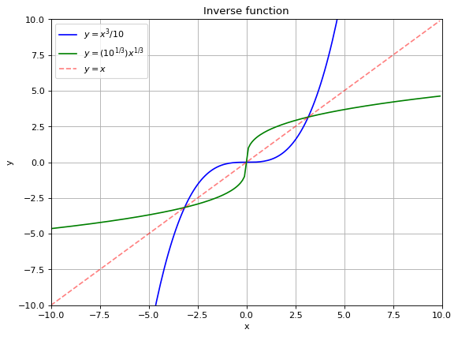

```python
################################################################################
# Let's see a Inverse Function
# Author: stevenlee, tw.steven@gmail.com
# Date: 2017.05.18
################################################################################
import numpy as np
import matplotlib.pyplot as plt

x = np.arange(-10.0, 10., 0.1)

f = (x**3)/10

# g is the inverse function of f
# g = (10x)^(1/3), use abs is to avoid error when x < 0
g = ((10*abs(x))**(1/3)) * (x/abs(x))

# Plot to figure
plt.figure(figsize=(8, 6), dpi=80)
plt.title('Inverse function')
plt.plot(x, f, 'b',label='$y=x^{3}/10$')
plt.plot(x, g, 'g',label='$y=(10^{1/3})x^{1/3}$')
plt.plot(x, x, 'r--',label='$y=x$',alpha=0.5)
plt.xlabel('x')
plt.ylabel('y')
plt.xlim([-10,10]) # Limit the display range
plt.ylim([-10,10]) # Limit the display range
plt.legend(loc=2)
plt.grid(True)
plt.show()
```

#### Radical Functions

For example: $ y = \sqrt[3]{(x^2-1)}$

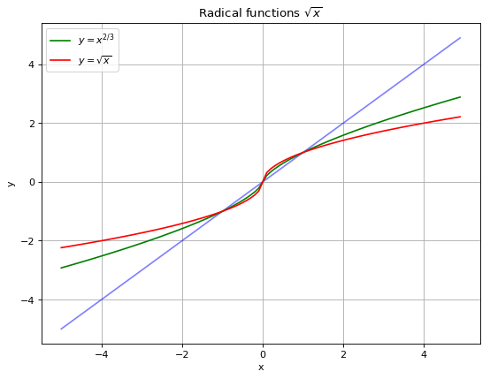

```python
################################################################################
# Let's see a Radical Function
# Author: stevenlee, tw.steven@gmail.com
# Date: 2017.05.18
################################################################################
import numpy as np
import matplotlib.pyplot as plt

x = np.arange(-5., 5., 0.1)

sign = (x/abs(x))

p = abs(x)**(2/3) * sign
q = (abs(x)**0.5) * sign

# Plot to figure
plt.figure(figsize=(8, 6), dpi=80)
plt.title('Radical functions $\sqrt{x}$')
plt.plot(x, x, 'b',alpha=0.5)
plt.plot(x, p, 'g',label='$y=x^{2/3}$')
plt.plot(x, q, 'r',label='$y=\sqrt{x}$')

plt.xlabel('x')
plt.ylabel('y')
plt.legend(loc=2)
plt.grid(True)
plt.show()
```

### Ch4. Exponential and Logarithmic Functions

#### Exponential Functions

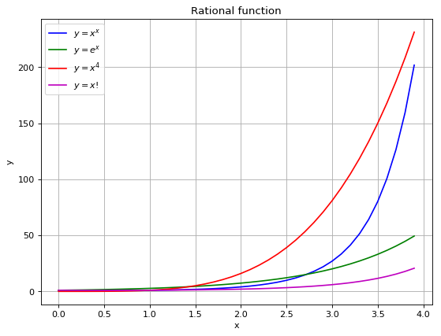

```python
################################################################################
# Let's see a Exponential Growth Function
# Author: stevenlee, tw.steven@gmail.com
# Date: 2017.05.18
################################################################################
import numpy as np
import matplotlib.pyplot as plt
from scipy.special import factorial # Factorial n!

# Change the range to see who grows faster!
x = np.arange(0., 4., 0.1)
# x = np.arange(0., 7., 0.1) # Don't show x^x, 7^7 is much biger than others

p = x**x            # x^x
q = np.exp(x)       # e^x
r = x**4            # x^4
n = factorial(x)    # x!

# Plot to figure
plt.figure(figsize=(8, 6), dpi=80)
plt.title('Rational function')
plt.plot(x, p, 'b',label='$y=x^x$')
plt.plot(x, q, 'g',label='$y=e^x$')
plt.plot(x, r, 'r',label='$y=x^4$')
plt.plot(x, n, 'm',label='$y=x!$')
plt.xlabel('x')
plt.ylabel('y')
plt.legend(loc=2)
plt.grid(True)
plt.show()
```

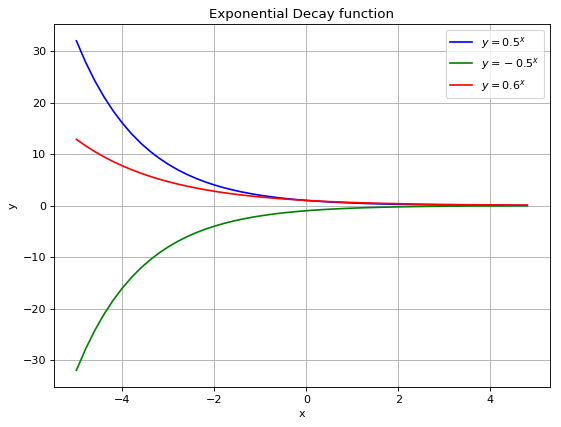

```python
################################################################################
# Let's see a Exponential Decay Function
# Author: stevenlee, tw.steven@gmail.com
# Date: 2017.05.18
################################################################################
import numpy as np
import matplotlib.pyplot as plt

x = np.arange(-5., 5., 0.2)

p = (0.5)**x
q = - p
r = (0.6)**x

# Plot to figure
plt.figure(figsize=(8, 6), dpi=80)
plt.title('Exponential Decay function')
plt.plot(x, p, 'b',label='$y=0.5^x$')
plt.plot(x, q, 'g',label='$y=-0.5^x$')
plt.plot(x, r, 'r',label='$y=0.6^x$')
plt.xlabel('x')
plt.ylabel('y')
plt.legend(loc=1)
plt.grid(True)
plt.show()
```

#### 4.3 e, the natural base

e is the natural base or called the **Euler number**. The discovery of the constant itself is credited to Jacob Bernoulli in 1683. He wrote:

$e = lim_{n \to \infty}(1 + \frac{1}{n})^n$

**Jacob Bernoulli (1655 - 1705)** https://en.wikipedia.org/wiki/Jacob_Bernoulli

[figure not shown]

By Niklaus Bernoulli (1662-1716) - [[2]](http://www.maa.org/EulerTour/Basel_Talks_by_Fred_and_Joel_in_Old_Aula/index.htm) [[3]](http://www.unigeschichte.unibas.ch/materialien/rektoren/jakob-bernoulli.html), Public Domain, [Link](https://commons.wikimedia.org/w/index.php?curid=266673)

**Logarithmic spiral $r = ae^{b\theta}$ (等角螺旋)**

[figure not shown]

By Morn the Gorn - Own work, Public Domain, [Link](https://commons.wikimedia.org/w/index.php?curid=9941801)

[figure not shown]

By NASA and European Space Agency - http://antwrp.gsfc.nasa.gov/apod/ap050428.html SOURCE OF 2ND VERSION: http://www.spacetelescope.org/images/heic0506a/ also bigger versions up to about 12000x8000 pixel available, Public Domain, [Link](https://commons.wikimedia.org/w/index.php?curid=3863746)

[figure not shown]

By NASA’s Aqua/MODIS satellite - http://visibleearth.nasa.gov/view_rec.php?id=6204, Public Domain, [Link](https://commons.wikimedia.org/w/index.php?curid=400656)

**Jacob Bernoulli's grave**

(Even he and his families are great mathematicians... disaster still happened...)

[figure not shown]

By Taxiarchos228 - Own work, [FAL](http://artlibre.org/licence/lal/en), [Link](https://commons.wikimedia.org/w/index.php?curid=39374112)

**Binominal theorem (二項式定理)**:

${\displaystyle (x+y)^{n}={n \choose 0}x^{n}y^{0}+{n \choose 1}x^{n-1}y^{1}+{n \choose 2}x^{n-2}y^{2}+\cdots +{n \choose n-1}x^{1}y^{n-1}+{n \choose n}x^{0}y^{n},} $

${\displaystyle {\tbinom {n}{k}} = {\frac {n!}{k!(n-k)!}} = _nC_k}$

Use Binominal theorem in e: ($y=1,x={\frac{1}{n}}$)

${\displaystyle (1+{\frac{1}{n}})^{n}={n \choose 0}{\frac{1}{n}}^{0}+{n \choose 1}{\frac{1}{n}}^{1}+{n \choose 2}{\frac{1}{n}}^{2}+\cdots +{n \choose {n-1}}{\frac{1}{n}}^{n-1}+{n \choose n}{\frac{1}{n}}^{n},} $

${\displaystyle (1+{\frac{1}{n}})^{n} = \frac{1}{0!}+\frac{1}{1!}+\frac{1}{2!}+\cdots+\frac{1}{(n-1)!}+\frac{1}{n!}}$

$e = \sum_{n=0}^{\infty}\frac{1}{n!}$

##### Factorial (n!)

Definition: $n! = n \cdot (n-1)!$ , n is positive integer

$1! = 1 \cdot 0!$, for consistency, we need to define 0! = 1

The function $f(x) = e^x$ is called the natural exponential function. The natural logarithm, or logarithm to base e, $g(x)=log_e(x)$, is the inverse function to the natural exponential function.

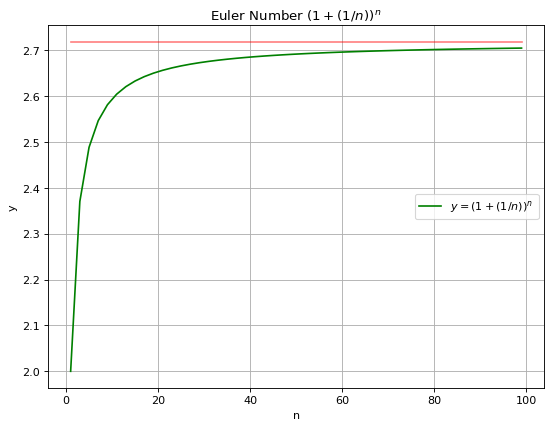

```python
################################################################################
# Let's see a Euler number
# Author: stevenlee, tw.steven@gmail.com
# Date: 2017.05.18
################################################################################
import numpy as np
import matplotlib.pyplot as plt

n = np.arange(1., 100., 2)

y = (1 + (1/n))**n
p = 0*n + np.e

# Plot to figure
plt.figure(figsize=(8, 6), dpi=80)
plt.title('Euler Number $(1+(1/n))^n$')
plt.plot(n, y, 'g',label='$y=(1+(1/n))^n$ ')
plt.plot(n, p, 'r',alpha=0.5)
plt.xlabel('n')
plt.ylabel('y')
plt.legend(loc=5)
plt.grid(True)
plt.show()
```

**Leonnhard Euler (1707-1783)** https://en.wikipedia.org/wiki/Leonhard_Euler

[figure not shown]

By [Jakob Emanuel Handmann](https://en.wikipedia.org/wiki/Jakob_Emanuel_Handmann) - 2. [Kunstmuseum Basel](http://sammlungonline.kunstmuseumbasel.ch/eMuseumPlus?service=ExternalInterface&module=collection&objectId=1429&viewType=detailView) 1. digitized version, the source (scanner) of the digitized image is unknown. The image was transferred from en.wiki ([en:Image:Leonhard Euler.jpg](https://en.wikipedia.org/wiki/Image:Leonhard_Euler.jpg)) under the {{PD-old}} license tag. Wars 16:56, 25 June 2006 (UTC), Public Domain, [Link](https://commons.wikimedia.org/w/index.php?curid=893656)

#### Logarithmic Functions

If $f(x) = b^x$, the inverse function $f^{-1}(x)=log_b(x)$, logarithm of x with base b, or we say "log base b of x"

For example,

$ 2^3 = 8 \to log_2(8) = 3$

##### Logarithm properties

- Product property: $log_b(mn) = log_b(m) + log_b(n)$
- Quotient property: $log_b(\frac{m}{n}) = log_b(m) - log_b(n)$
- Power property: $log_b(m^n) = n \cdot log_b(m)$

##### $log_b(0) \to -\infty$

$log_b(0)$ is not defined. Because there is no y meets $b^y = 0$

But, if we say $b^y \to 0$, then, $log_b(0) \to -\infty$

##### $log_b(1) = 0$

Because $b^0 = 1$, logarithm function always pass point (1,0)

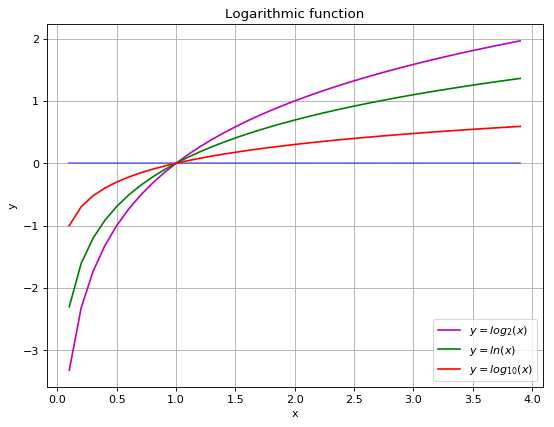

```python
################################################################################
# Let's see a Logarithmic Function
# Author: stevenlee, tw.steven@gmail.com
# Date: 2017.05.18
################################################################################
import numpy as np
import matplotlib.pyplot as plt

step = 0.1 # give smaller step, one x will close to 0, log(0) -> -inf

x = np.arange(0.1, 4., step)

p = 0*x
q = np.log(x)    # Natural log
r = np.log10(x)  # 10-based log
s = np.log2(x)   # 2-based log

# Plot to figure
plt.figure(figsize=(8, 6), dpi=80)
plt.title('Logarithmic function')
plt.plot(x, p, 'b',alpha=0.5)
plt.plot(x, s, 'm',label='$y=log_{2}(x)$')
plt.plot(x, q, 'g',label='$y=ln(x)$')
plt.plot(x, r, 'r',label='$y=log_{10}(x)$')
plt.xlabel('x')
plt.ylabel('y')
plt.legend(loc=4)
plt.grid(True)
plt.show()
```

### Ch5. Rational Functions

A rational function is any function which can be defined by a rational fraction.

$f(x) = \frac{P(x)}{Q(x)}$

**Notice: What happened when the denominator equals 0**

#### Properties

- Addition
- Subtraction
- Multiplication
- Division (with no surprise~)

#### Variation

- Direct variation: $y = kx, k≠0$
- Inverse variation $y = \frac{k}{x}, k≠0$
- Joint variation: $z = kxy$, z varies jointly with x and y

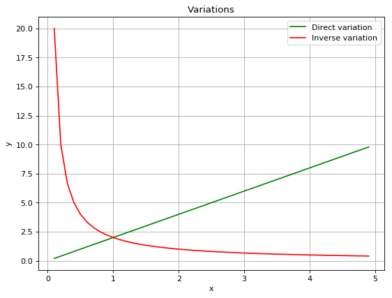

```python
################################################################################
# Let's see the direct and inverse variation
# Author: stevenlee, tw.steven@gmail.com
# Date: 2017.05.18
################################################################################
import numpy as np
import matplotlib.pyplot as plt

x = np.arange(0.1, 5., 0.1)
y_dir = 2*x
y_inv = 2 / x

# Plot to figure
plt.figure(figsize=(8, 6), dpi=80)
plt.title('Variations')
plt.plot(x, y_dir, 'g',label='Direct variation')
plt.plot(x, y_inv, 'r',label='Inverse variation')
plt.xlabel('x')
plt.ylabel('y')
plt.legend(loc=1)
plt.grid(True)
plt.show()
```

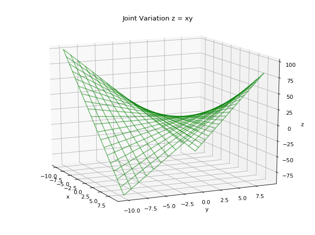

```python
################################################################################
# Let's see the joint variation
# Author: stevenlee, tw.steven@gmail.com
# Date: 2017.05.18
################################################################################
import numpy as np
import matplotlib.pyplot as plt
from mpl_toolkits.mplot3d import axes3d

# Prepare the data
x = []
y = []
l = np.arange(-10., 10., 1)
length = len(l)
for i in range(length):
    x.append(l)

x = np.asarray(x)
x.reshape((length,length))
y = np.transpose(x)

# Joint variation function z = xy
z = x * y

# Plot to figure
fig = plt.figure(figsize=(8, 6), dpi=80)
ax = fig.add_subplot(111, projection='3d')

# Plane z = xy
ax.plot_wireframe(x, y, z,color='g', rstride=1, cstride=1,alpha=0.5)

ax.set_xlabel('x')
ax.set_ylabel('y')
ax.set_zlabel('z')
ax.view_init(elev=15, azim=-25)
plt.title('Joint Variation z = xy')
plt.tight_layout()
plt.show()
```

#### Solve the equation

Wait a minute, what is "Solve"?

Let's solve the equation x + 3 = 3x -1 ? Simple, 4 = 2x, so, x = 2. Solved!

Let's see the two lines:

$y_1 = x + 3$

$y_2 = 3x -1$

The solution is the cross point of the two lines! "Cross" means: You have same outputs when inputs are the same.

One solution means **"only one cross point"**.

That implies:

- Sometimes, you have no solution
- Sometimes, you have 2 or more solutions
- Sometimes, your solution is another equation (infinite number)

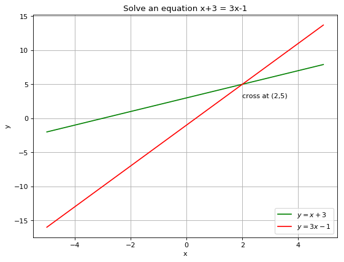

```python
################################################################################
# Let's solve the equation
# Author: stevenlee, tw.steven@gmail.com
# Date: 2017.05.18
################################################################################
import numpy as np
import matplotlib.pyplot as plt

x = np.arange(-5., 5., 0.1)
y1 = x + 3
y2 = 3*x -1

# Plot to figure
plt.figure(figsize=(8, 6), dpi=80)
plt.title('Solve an equation x+3 = 3x-1')
plt.plot(x, y1, 'g',label='$y=x+3$')
plt.plot(x, y2, 'r',label='$y=3x-1$')
plt.text(2,3,'cross at (2,5)')
plt.xlabel('x')
plt.ylabel('y')
plt.legend(loc=4)
plt.grid(True)
plt.show()
```

#### Even function and Odd function

Even function: $f(-x) = f(x)$

Odd function: $f(-x) = -f(x)$

Let's check the "Symmetry Axis". What do you find?

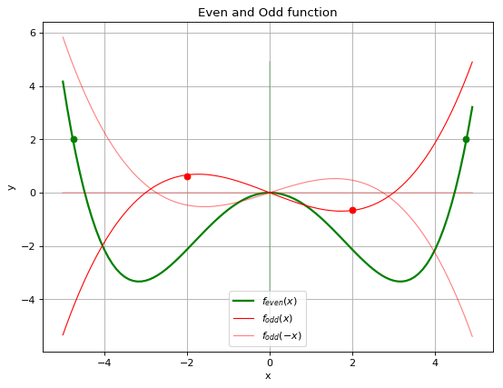

```python
################################################################################
# Let's see even and odd function
# Author: stevenlee, tw.steven@gmail.com
# Date: 2017.05.18
################################################################################
import numpy as np
import matplotlib.pyplot as plt

x = np.arange(-5., 5., 0.1)
y_even = (x**4 - 20*(x**2)) / 30
y_oddp = (2*(x**3) - 18*x) / 30
y_oddn = (2*((-x)**3) - 15*(-x)) / 30

zero = 0*x

# Plot to figure
plt.figure(figsize=(8, 6), dpi=80)
plt.title('Even and Odd function')

# Even function
plt.plot(x, y_even, 'g',label='$f_{even}(x)$',linewidth=2)

# Odd functions
plt.plot(x, y_oddp, 'r',label='$f_{odd}(x)$',linewidth=1)
plt.plot(x, y_oddn, 'r',label='$f_{odd}(-x)$',linewidth=1,alpha=0.5)

# Plot horizontal and vertical line for reference
plt.plot(zero, x, 'g',alpha=0.25)
plt.plot(x, zero, 'r',alpha=0.25)

# Plot the points on even function
plt.plot(4.75, 2, 'go')
plt.plot(-4.75, 2, 'go')
# Plot the points on odd function
plt.plot(2, -0.63, 'ro')
plt.plot(-2, 0.63, 'ro')

plt.xlabel('x')
plt.ylabel('y')
plt.legend(loc=8)
plt.grid(True)
plt.show()
```

**Let's see a rational function $f(x)=\frac{P(x)}{Q(x)}$ :**

(Ignore "divided by zero" for now)

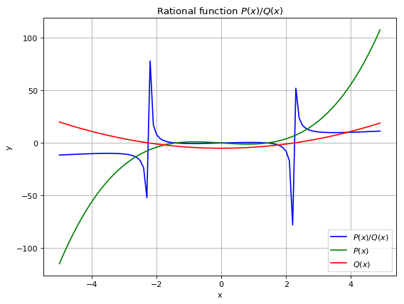

```python
################################################################################
# Let's see a Rational Function
# Author: stevenlee, tw.steven@gmail.com
# Date: 2017.05.18
################################################################################
import numpy as np
import matplotlib.pyplot as plt

x = np.arange(-5., 5., 0.1)

p = (x**3) - (2*x)
q = (x**2 -5)
y = 2*p / q

# Plot to figure
plt.figure(figsize=(8, 6), dpi=80)
plt.title('Rational function $P(x)/Q(x)$')
plt.plot(x, y, 'b',label='$P(x)/Q(x)$')
plt.plot(x, p, 'g',label='$P(x)$')
plt.plot(x, q, 'r',label='$Q(x)$')
plt.xlabel('x')
plt.ylabel('y')
plt.legend(loc=4)
plt.grid(True)
plt.show()
```

### Ch6. Data Analysis and Statistics

#### Combination

Combination is a selection of r objects from n objects, where order is not considered.

$_nC_r = \frac{n!}{(n-r)! \cdot r!}$

#### Pascal's Triangle

https://en.wikipedia.org/wiki/Pascal%27s_triangle

[figure not shown]

By Hersfold on the English Wikipedia - Own work, Public Domain, [Link](https://commons.wikimedia.org/w/index.php?curid=3902538)

[figure not shown]

By Gjacquenot - Own work, [CC BY-SA 4.0](http://creativecommons.org/licenses/by-sa/4.0), [Link](https://commons.wikimedia.org/w/index.php?curid=40243580)

#### Binominal Expansions

$ (a+b)^n = _nC_0a^nb^0 + _nC_1a^{n-1}b^1 + _nC_2a^{n-2}b^2+...+ _nC_na^{0}b^n$

Recall the definition of e:

$ (1+ \frac{1}{n})^n = _nC_0 + \frac{_nC_1}{n} + \frac{_nC_2}{n^2} + ... +\frac{_nC_n}{n^n}$

$ (1+ \frac{1}{n})^n = 1! + 1! + \frac{(n-1)}{n \cdot 2!} + ... +\frac{1}{n!}$

#### Binominal Experiment

Condition:

- Each trial has only two possible result: Success or Fail (Bernoulli Trial)
- n independent trial
- The probability for "Success" is p, and for "Fail": (1-p)

Then, the probability of n trial with k successes is:

$P_{k-successes} = (_nC_k) \cdot p^k \cdot (1-p)^{(n-k)} $

This is called **Binominal Distribution**

Let's say n=1, $P_{success} = p$, which is **Bernoulli Distribution**

#### Normal Distribution ( = Gaussian Distribution)

"Distribution" is a way to "model" the facts. "Modeling" is to describe the relationships of observed facts. Normal distribution is using a bell-shaped curve to describe the observations.

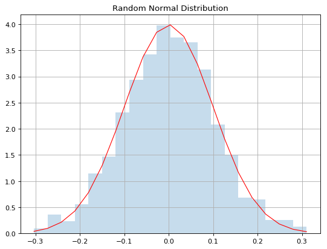

```python
################################################################################
# Normal distribution
# Author: stevenlee, tw.steven@gmail.com
# Date: 2017.05.18
################################################################################
import numpy as np
import matplotlib.pyplot as plt

mu, sigma = 0, 0.1 # mean and standard deviation
s = np.random.normal(mu, sigma, 1000)

plt.figure(figsize=(8, 6), dpi=80)
# Histogram:
count, bins, ignored = plt.hist(s, 20, normed=True,alpha=0.25)

# Normal distribution:
f = 1/(sigma * np.sqrt(2 * np.pi)) * np.exp( - (bins - mu)**2 / (2 * sigma**2) )
plt.plot(bins, f, linewidth=1, color='r')
plt.title('Random Normal Distribution')
plt.grid(True)
plt.show()
```

**[Seeing the Theory]** http://students.brown.edu/seeing-theory/

```python
from IPython.display import HTML
HTML('<iframe width="800" height="480" src="http://students.brown.edu/seeing-theory/"></iframe>')
```

[interactive chart not shown]

### Ch7. Sequence and Series

Sequence is a function whose domain is a set of consecutive integers(1,2,3...n). Each integer generate a term. The terms of the sequence is called "range".

**Series is the form of adding sequence items.** $S = a_0 + a_1 + a_2 + ...$

In simple:

- domain is the input set, contains consecutive integers
- range is the output set, contains terms

For example, $a_n = 2n+5$ : First term $a_1 = 7$, secound term $a_2 = 9$ ...

#### Summation Notation $\sum$

Finite series: $2 + 4 + 6 + 8 = \sum_{i=1}^{4}2i$

Infinite series: $2 + 4 + 6 + 8 + ... = \sum_{i=1}^{\infty}2i$

##### Special formulas

- $\sum_{i=1}^{n}1 = n$
- $\sum_{i=1}^{n}i = \frac{n(n+1)}{2}$
- $\sum_{i=1}^{n}i^2 = \frac{n(n+1)(2n+1)}{6}$

**Sum of series is preparing for Integral(積分)**

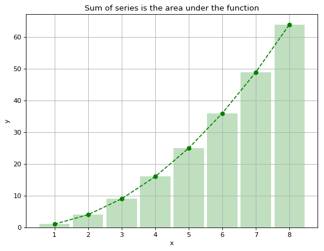

```python
################################################################################
# Sum of series
# Author: stevenlee, tw.steven@gmail.com
# Date: 2017.05.18
################################################################################
import numpy as np
import matplotlib.pyplot as plt

x = np.arange(1., 9., 1)
y = (x**2)

plt.figure(figsize=(8, 6), dpi=80)
plt.plot(x,y,'go--')
plt.bar(x, y, width=0.9, bottom=None,color='g',alpha=0.25, align='center')
plt.title('Sum of series is the area under the function')
plt.xlabel('x')
plt.ylabel('y')
plt.grid(True)
plt.show()
```

##### Arithmetic sequence 等差數列 : the distance between 2 terms is the same

$a_n = a_1 + (n-1)\cdot r$

Sum of arithmetic sequence: Area of trapezoid (梯形面積公式)

$ S_n = n \cdot (\frac{a_1+a_n}{2})$

##### Geometric sequence 等比數列：the ratio between 2 terms is the same

$a_n = a_1r^{n-1}$

Sum of geometric sequence:

$ S_n = a_1(\frac{1-r^n}{1-r})$

If r < 1, $n \to \infty$ , $ S_n = a_1(\frac{1}{1-r})$

**Wait a minute, why the name "Arithmetic" and "Geometric"?**

In a arithmetric sequence, each number is the arithmetic mean of the number adjacent to it. For example, in the arithematic sequence "1,3,5,7,9... ", $5 = \frac{3+7}{2}$ (arithematic mean)

In a geometric sequence, each number is the geometric mean of the numbers adjacent to it. For example, in the geometric sequence "1,2,4,8,16... ", $4 = \sqrt{2 \times 8}$ (geometric mean)

**I know arithmetic mean(算數平均),but what is geometric mean(幾何平均)?**

Geometric mean is to find a square that have same area as a rectangle. $d^2 = a \times b$

$Mean_{arithmetic} = \frac{\sum_{i=1}^{n}x_i}{n} $

$Mean_{geometric} = (\prod_{i=1}^{n}x_i)^{\frac{1}{n}} $

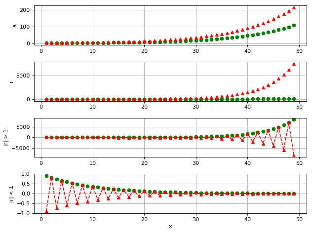

```python
################################################################################
# Geometric series
# Author: stevenlee, tw.steven@gmail.com
# Date: 2017.05.19
################################################################################
import numpy as np
import matplotlib.pyplot as plt

x = np.arange(1., 50., 1)
r=1.1
y_11 = (r**x)
y_12 = 2 * (r**x)

r = 1.1
r2 = 1.2
y_21 = (r**x)
y_22 = ((r2)**x)

a_1 = 1.1
r = 1.2
y_31 = a_1 * (r**x)
y_32 = a_1 * ((-r)**x)

a_1 = 1
r = 0.9
y_41 = a_1 * (r**x)
y_42 = a_1 * ((-r)**x)

plt.figure(num=None, figsize=(8, 6), dpi=80, facecolor='w', edgecolor='k')
plt.title('Geometric Series')
plt.subplot(411)
plt.plot(x,y_11,'go',x,y_12,'r^')
plt.grid(True)
plt.ylabel('a')


plt.subplot(412)
plt.plot(x,y_21,'go',x,y_22,'r^')
plt.grid(True)
plt.ylabel('r')

plt.subplot(413)
plt.plot(x,y_31,'go',x,y_32,'r^--')
plt.grid(True)
plt.ylabel('|r| > 1')

plt.subplot(414)
plt.plot(x,y_41,'go',x,y_42,'r^--')
plt.grid(True)
plt.ylabel('|r| < 1')

plt.xlabel('x')
plt.tight_layout()
plt.show()
```

#### Find Sums of Infinite Geometric Series

Why don't we find the sum of infinite arithematic series? If $n \to \infty$, $ S_n = n \cdot (\frac{a_1+a_n}{2})$, $S_{\infty} \to \infty$

Then, sum of infinite geometric series wont' go infinite?

$a_n = a_1r^{n-1}$

$ S_n = a_1(\frac{1-r^n}{1-r})$

If r = 0, $ S_{\infty} = a_1(\frac{1-0^{\infty}}{1-0}) = a_1$

If |r| < 1, $ S_{\infty} = a_1(\frac{1}{1-r}) $

If |r| ≥ 1, the series has no **definite** sum

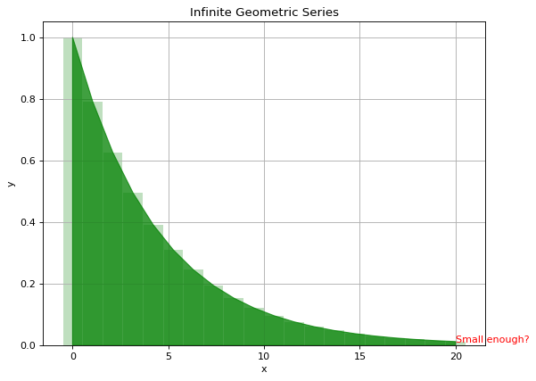

```python
################################################################################
# Infinite Geometric series
# Author: stevenlee, tw.steven@gmail.com
# Date: 2017.05.19
################################################################################
import numpy as np
import matplotlib.pyplot as plt

# r=0.9
r=0.8
x = np.linspace(0, 20, 20)
y = (r**x)

# for plotting
x=np.append(x,x[-1])
y=np.append(y,0)
x=np.append(x,0)
y=np.append(y,0)

plt.figure(figsize=(8, 6), dpi=80)
plt.bar(x, y, width=1.0, bottom=None,color='g',alpha=0.25)
plt.fill(x, y, zorder=10,color='g',alpha=0.75)
plt.grid(True, zorder=5)
plt.title('Infinite Geometric Series')
plt.ylabel('y')
plt.xlabel('x')
plt.text(20,0.01,'Small enough?',color='r')
plt.show()
```

### Ch8. Quadratic Relations and Conic Sections

#### Parabolas (拋物線)

A parabola is defined by a point (focus point) and a line (directrix). Any point on a parabola has same distance to focus point and to directrix.

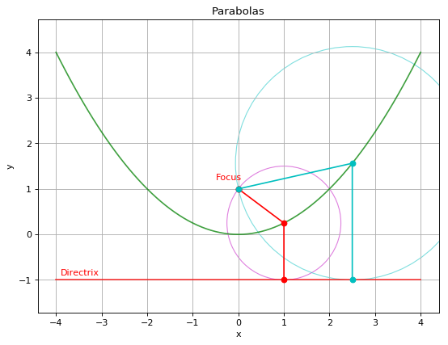

```python
################################################################################
# Parabola
# Author: stevenlee, tw.steven@gmail.com
# Date: 2017.05.19
################################################################################
import numpy as np
import matplotlib.pyplot as plt

x = np.arange(-4., 4.1, 0.1)
y = 0.25*x**2
directrix = 0*x + (-1)

fig = plt.figure(figsize=(8, 6), dpi=80)
ax = fig.gca()
ax.cla()

# Focus
plt.plot([0],[1],'ro')
plt.text(-0.5,1.2,'Focus',color='r')

# Directrix
plt.plot(x, directrix, color='r',alpha=0.75)
plt.text(-3.9,-.9,'Directrix',color='r')

# Parabola
plt.plot(x, y,color='g',alpha=0.75)

# Circle 1
px = 1
py = 0.25*(px**2)
plt.plot([px,px,0],[-1,py,1],'ro-')
circle1 = plt.Circle(xy=(px, py),radius=(py+1), color='m',fill=False,alpha=0.5)
ax.add_artist(circle1)

# Circle 2
px = 2.5
py = 0.25*(px**2)
plt.plot([px,px,0],[-1,py,1],'co-')
circle2 = plt.Circle(xy=(px, py),radius=(py+1), color='c',fill=False,alpha=0.5)
ax.add_artist(circle2)

plt.grid(True)
plt.title('Parabolas')
plt.ylabel('y')
plt.xlabel('x')
plt.axis('equal')
plt.show()
```

#### Additional Material: Slope of Parabola

Let's see the slope of parabola $y=0.25 x^2$

$dy/dx =(0.25) \cdot 2x$

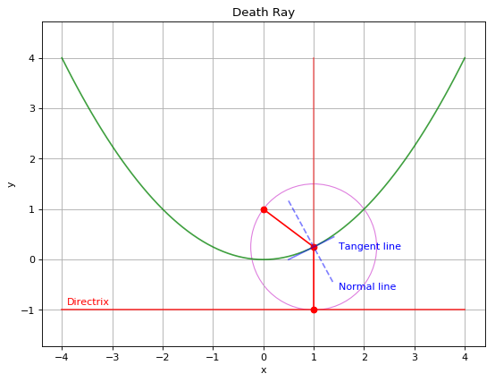

```python
################################################################################
# Parabola Slope
# Author: stevenlee, tw.steven@gmail.com
# Date: 2017.05.19
################################################################################
import numpy as np
import matplotlib.pyplot as plt

x = np.arange(-4., 4.1, 0.1)
y = 0.25*x**2
directrix = 0*x + (-1)

dy = 0.5*x

plt.figure(figsize=(8, 6), dpi=80)
ax = plt.gca()
ax.cla()


# Focus
# plt.plot([0],[1],'ro')
# plt.text(-0.5,1.2,'Focus',color='r')

# Directrix
plt.plot(x, directrix, color='r',alpha=0.75)
plt.text(-3.9,-.9,'Directrix',color='r')

# Parabola
plt.plot(x, y,color='g',alpha=0.75)

# Circle 1
px = 1
py = 0.25*(px**2)
plt.plot([px,px,0],[-1,py,1],'ro-')
circle1 = plt.Circle(xy=(px, py),radius=(py+1), color='m',fill=False,alpha=0.5)
ax.add_artist(circle1)

# Tangent
a = px+x
b = py+dy
plt.plot(a[35:45], b[35:45],'b-',alpha=0.5)
plt.text(1.5,0.2,'Tangent line',color='b')

# Normal
theta = np.arctan(b[1]-b[0])/(a[1]-a[0])
theta2 = np.pi/2 - theta
slope_minus = np.tan(theta2)
c = py - slope_minus * x
plt.plot(a[35:45], c[35:45],'b--',alpha=0.5)
plt.text(1.5,-0.6,'Normal line',color='b')

# Reflect line
plt.plot([px,px],[py,4],'r-',alpha=0.5)

plt.grid(True)
plt.title('Death Ray')
plt.ylabel('y')
plt.xlabel('x')
plt.axis('equal')
plt.show()
```

#### Circle

Center $(x_0,y_0)$ Radius r

$ (x-x_0)^2 + (y-y_0)^2 = r^2 $

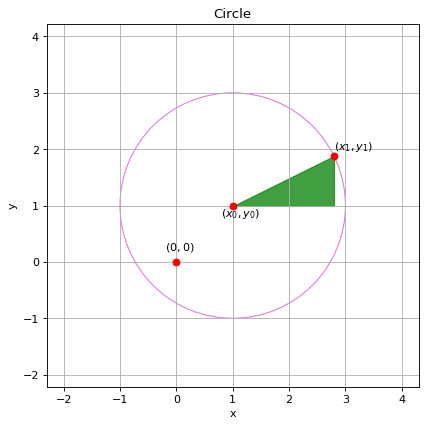

```python
################################################################################
# Circle
# Author: stevenlee, tw.steven@gmail.com
# Date: 2017.05.19
################################################################################
import numpy as np
import matplotlib.pyplot as plt

# Parameter
x_0,y_0 = 1,1
r = 2

x = np.arange(-4., 4.1, 0.1)

plt.figure(figsize=(6, 6), dpi=80)
ax = plt.gca()
ax.cla() # clear things for fresh plot
# Circle
circle1 = plt.Circle(xy=(x_0, y_0),radius=r, color='m',fill=False,alpha=0.5)
ax.add_artist(circle1)

# Triangle
px = 1.8+x_0
py = np.sqrt(r**2 - (px-x_0)**2)+y_0
plt.fill([x_0,px,px,x_0], [y_0,y_0,py,y_0],color='g',alpha=0.75)

# Rectangle
plt.plot([-2,4,4,-2],[-2,-2,4,4],color='w',alpha=0.1)

# Points
plt.plot([0,x_0,px],[0,y_0,py],'ro')

# Texts
plt.text(-0.2,0.2,'$(0,0)$')
plt.text(0.8,0.8,'$(x_0,y_0)$')
plt.text(2.8,2,'$(x_1,y_1)$')

plt.grid(True)
plt.title('Circle')
plt.ylabel('y')
plt.xlabel('x')
plt.axis('equal')
plt.show()
```

#### Ellipses

Ellipse is "Two focus" cirle, say $f_1,f_2$

Ellipse is the set of point P in the plane that $d_1 + d_2 = foci = constant$

where $d_1,d_2$ are distances from P to $f_1$ and P to $f_2$

Ellipse is $\frac{x^2}{a^2} + \frac{y^2}{b^2} = 1$

Center of ellipse c:

If a > b: $a^2 - b^2 = c^2 $

```
d1+d2 = 10.0
d3+d4 = 10.0
```

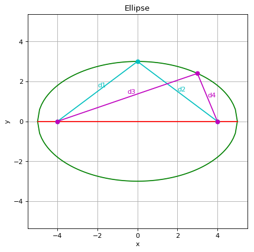

```python
################################################################################
# Ellipse
# Author: stevenlee, tw.steven@gmail.com
# Date: 2017.05.19
################################################################################
import numpy as np
import matplotlib.pyplot as plt

a,b = 5.,3.
c = np.sqrt(a**2 - b**2)

x = np.arange(-a, a, 0.1)
y = pow((1.-(x**2)/(a**2)),0.5)*b

# Append (a,0) because np.sqrt(0) is not avaliable
x = np.append(x,a)
y = np.append(y,0.0)

# Mirror to negative
y_min = -y

# Pick two Test Point:
tp_x = [x[50], x[80]]
tp_y = [y[50], y[80]]

d1 = np.sqrt((-c-tp_x[0])**2 + (tp_y[0])**2)
d2 = np.sqrt((c-tp_x[0])**2 + (tp_y[0])**2)

d3 = np.sqrt((-c-tp_x[1])**2 + (tp_y[1])**2)
d4 = np.sqrt((c-tp_x[1])**2 + (tp_y[1])**2)

print('d1+d2 =',d1+d2)
print('d3+d4 =',d3+d4)

plt.figure(figsize=(6, 6), dpi=80)

plt.plot(x,y,'g')     # Draw Ellipse upper part
plt.plot(x,y_min,'g') # Draw Ellipse lower part
plt.plot([-a,a],[0,0],'r') # Draw Center line

plt.plot([-c,tp_x[0],c],[0,tp_y[0],0],'co-') # Draw Test Point 0
plt.plot([-c,tp_x[1],c],[0,tp_y[1],0],'mo-') # Draw Test Point 1
plt.text((tp_x[0]-c)/2,0.2+tp_y[0]/2,'d1',color='c')
plt.text((tp_x[0]+c)/2,tp_y[0]/2,'d2',color='c')
plt.text((tp_x[1]-c)/2,0.2+tp_y[1]/2,'d3',color='m')
plt.text((tp_x[1]+c)/2,tp_y[1]/2,'d4',color='m')

plt.grid(True)
plt.title('Ellipse')
plt.ylabel('y')
plt.xlabel('x')
plt.axis('equal')
plt.show()
```

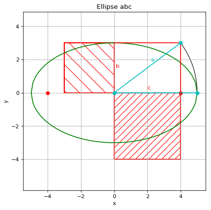

```python
################################################################################
# Ellipse a,b,c
# Author: stevenlee, tw.steven@gmail.com
# Date: 2017.05.19
################################################################################
import numpy as np
import matplotlib.pyplot as plt
import matplotlib.patches as patches
a,b = 5.,3.
c = np.sqrt(a**2 - b**2)

x = np.arange(-a, a, 0.1)
y = pow((1.-(x**2)/(a**2)),0.5)*b

# Append (a,0) because np.sqrt(0) is not avaliable
x = np.append(x,a)
y = np.append(y,0.0)

# Mirror to negative
y_min = -y


plt.figure(figsize=(6, 6), dpi=80)
ax = plt.gca()
ax.cla()

plt.plot(x,y,'g')     # Draw Ellipse upper part
plt.plot(x,y_min,'g') # Draw Ellipse lower part
plt.plot([-c,c],[0,0],'ro') # Draw Center
plt.plot([c,c,0],[0,b,b],'r-')

plt.plot([a,0,c],[0,0,b],'co-')

# Create a Rectangle patch
rect = patches.Rectangle((-b,0),b,b,linewidth=2,edgecolor='r',fill=False,hatch='\\',)
rect2 = patches.Rectangle((0,-c),c,c,linewidth=2,edgecolor='r',fill=False,hatch='//',)

theta = np.degrees(np.arctan(b/c))
arc = patches.Arc((0,0), 2*a, 2*a, angle=0.0, theta1=0.0, theta2=theta)

# Add the patch to the Axes
ax.add_patch(rect)
ax.add_patch(rect2)
ax.add_patch(arc)

plt.text(c/2,0.2,'c',color='r')
plt.text(0.1,b/2,'b',color='r')
plt.text(a/2-0.3,b/2+0.4,'a',color='c')

plt.grid(True)
plt.title('Ellipse abc')
plt.ylabel('y')
plt.xlabel('x')
plt.axis('equal')
plt.show()
```

#### Hyperbolas

Hyperbola also has two focus, say $f_1,f_2$

Hyperbola is the set of point P in the plane that $d_1 - d_2 = foci = constant$

where $d_1,d_2$ are distances from P to $f_1$ and P to $f_2$

Hyperbla is $\frac{x^2}{a^2} - \frac{y^2}{b^2} = 1$

Focus at (c,0): $c^2 = a^2 + b^2$

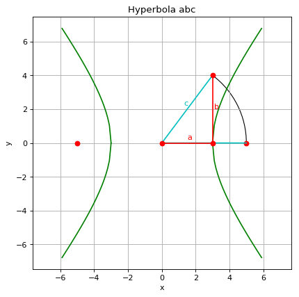

```python
################################################################################
# Hyperbolas
# Author: stevenlee, tw.steven@gmail.com
# Date: 2017.05.19
################################################################################
import numpy as np
import matplotlib.pyplot as plt
import matplotlib.patches as patches

a,b = 3.,4.
c = np.sqrt(a**2 + b**2)

x = np.arange(a, 2.0*a, 0.1)
y = pow(((x**2)/(a**2)-1),0.5)*b

plt.figure(figsize=(6, 6), dpi=80)
ax = plt.gca()
ax.cla()

plt.plot(x,y,'g')     # Draw Hyperbola right upper part
plt.plot(x,-y,'g')     # Draw Hyperbola right lower part
plt.plot(-x,y,'g')     # Draw Hyperbola left upper part
plt.plot(-x,-y,'g')     # Draw Hyperbola left lower part
plt.plot([-c,c],[0,0],'ro') # Draw Center

plt.plot([a,0,c],[b,0,0],'c-') # Draw c
plt.plot([0,a,a],[0,0,b],'ro-') # Draw a,b

theta = np.degrees(np.arctan(b/a))
arc = patches.Arc((0,0), 2*c, 2*c, angle=0.0, theta1=0.0, theta2=theta)
ax.add_patch(arc)

plt.text(a/2,0.2,'a',color='r')
plt.text(a+0.1,b/2,'b',color='r')
plt.text(a/2-0.2,b/2+0.2,'c',color='c')

plt.grid(True)
plt.title('Hyperbola abc')
plt.ylabel('y')
plt.xlabel('x')
plt.axis('equal')
plt.show()
```

**[Think] Compare Circle / Ellipse / Parabola / Hyperbola**

[figure not shown]

By http://commons.wikimedia.org/wiki/User:Magister_Mathematicae - http://commons.wikimedia.org/wiki/File:Secciones_c%C3%B3nicas.svg, [CC BY-SA 3.0](http://creativecommons.org/licenses/by-sa/3.0), [Link](https://commons.wikimedia.org/w/index.php?curid=18556148)

### Ch9. Trigonometric Ratios and Functions

Consider a right triangle that has an acute angel $\theta$. The three sides are: hypotenus(h), adjacent(a) and opposite(o).

$ sin(\theta) = \frac{opposite}{hypotenus}$, $ csc(\theta) = \frac{1}{sin(\theta)}$

$ cos(\theta) = \frac{adjacent}{hypotenus}$, $ sec(\theta) = \frac{1}{cos(\theta)}$

$ tan(\theta) = \frac{opposite}{adjacent}$, $ cot(\theta) = \frac{1}{tan(\theta)}$

[figure not shown]

By Original: [Steven G. Johnson](https://en.wikipedia.org/wiki/User:Stevenj) at [English Wikipedia](https://en.wikipedia.org/wiki/) Derivative work: Limaner - Circle-trig6.png, [CC BY-SA 3.0](http://creativecommons.org/licenses/by-sa/3.0/), [Link](https://commons.wikimedia.org/w/index.php?curid=770792)

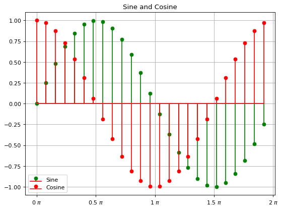

```python
################################################################################
# Sine and Cosine
# Author: stevenlee, tw.steven@gmail.com
# Date: 2017.05.19
################################################################################
import matplotlib.pyplot as plt
import matplotlib.ticker as tck
import numpy as np

fs = 25 # sample rate: How many point in 1 cycle
f = 1 # the frequency of the signal (Hz)

x = np.arange(fs)
rad = [2*np.pi*f * (i/fs) for i in np.arange(fs)]
tick = [2 * (i/fs) for i in np.arange(fs)] # tick is only for drawing x axis
y_sin = np.sin(rad)
y_cos = np.cos(rad)

plt.figure(figsize=(8, 6), dpi=80)
ax = plt.gca()
ax.cla()
ax.xaxis.set_major_formatter(tck.FormatStrFormatter('%g $\pi$'))
ax.xaxis.set_major_locator(tck.MultipleLocator(base=0.5))

plt.title('Sine and Cosine')
plt.stem(tick, y_sin, linefmt='g-', markerfmt='go', basefmt='r-',label='Sine')
plt.stem(tick, y_cos, linefmt='r-', markerfmt='ro', label='Cosine')
plt.legend(loc=3)
plt.grid(True)
plt.show()
```

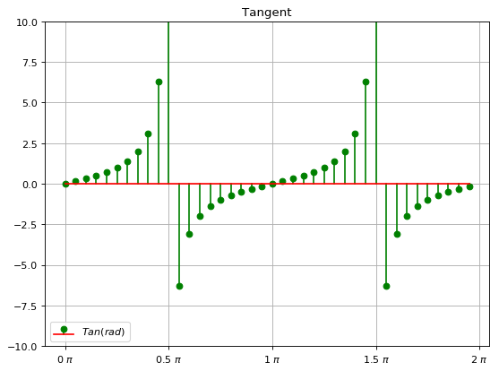

```python
################################################################################
# Tangent
# Author: stevenlee, tw.steven@gmail.com
# Date: 2017.05.19
################################################################################
import matplotlib.pyplot as plt
import matplotlib.ticker as tck
import numpy as np

fs = 40 # sample rate: How many point in 1 cycle
f = 1 # the frequency of the signal (Hz)

x = np.arange(fs)
rad = [2*np.pi*f * (i/fs) for i in np.arange(fs)]
tick = [2 * (i/fs) for i in np.arange(fs)] # tick is only for drawing x axis
y_tan = np.tan(rad)

plt.figure(figsize=(8, 6), dpi=80)
ax = plt.gca()
ax.cla()
ax.xaxis.set_major_formatter(tck.FormatStrFormatter('%g $\pi$'))
ax.xaxis.set_major_locator(tck.MultipleLocator(base=0.5))

plt.title('Tangent')
plt.stem(tick, y_tan, linefmt='g-', markerfmt='go', basefmt='r-',label='$Tan(rad)$')
plt.legend(loc=3)
plt.ylim([-10,10])
plt.grid(True)
plt.show()
```

#### Degree and Radius

$ 360^o = 2\pi$

$\pi = \frac{C}{d} $, where C is circumference, d is diameter

**Do you know $\pi$? Think again**

https://en.wikipedia.org/wiki/Pi

[figure not shown]

By Lucas V. Barbosa - Own work, Public Domain, [Link](https://commons.wikimedia.org/w/index.php?curid=25112326)

#### Law of Sines

The area T of any triangle can be written as one half of its base times its height. Selecting one side of the triangle as the base, the height of the triangle relative to that base is computed as the length of another side times the sine of the angle between the chosen side and the base. Thus, depending on the selection of the base the **area of the triangle** can be written as any of:

${\displaystyle T={\frac {1}{2}}b(c\sin A)={\frac {1}{2}}c(a\sin B)={\frac {1}{2}}a(b\sin C)\,.}$

Multiplying these by 2/abc gives

${\displaystyle {\frac {2T}{abc}}={\frac {\sin A}{a}}={\frac {\sin B}{b}}={\frac {\sin C}{c}}\,.} $

From: https://en.wikipedia.org/wiki/Law_of_sines

#### Law of Cosines

${\displaystyle c^{2}=a^{2}+b^{2}-2ab\cos \gamma ,}$

[figure not shown]

By David Weisman (Dweisman) - En-Wiki. Original description is/was [here](https://en.wikipedia.org/wiki/Image:TriangleWithNotations.svg), Public Domain, [Link](https://commons.wikimedia.org/w/index.php?curid=2596911)

Proof of Law of Cosines: https://en.wikipedia.org/wiki/Law_of_cosines

#### Heron's Area Formula

Heron's formula states that the area of a triangle whose sides have lengths a, b, and c is

${\displaystyle A={\sqrt {s(s-a)(s-b)(s-c)}},},$

where s is the **semiperimeter** of the triangle; that is,

${\displaystyle s={\frac {a+b+c}{2}}.}$

**semiperimeter**

The area A of any triangle is the product of its **inradius** (the radius of its inscribed circle) and its semiperimeter:

${\displaystyle A=rs.}$

https://en.wikipedia.org/wiki/Semiperimeter

**Unit Circle** The circle with radius = 1. That is $x^2+y^2=1$

Too simple? Yes, it is simple. We may connect e, i and trigometry in one place:

[figure not shown]

By Original: Gunther Derivative work: Wereon - This file was derived from Euler's formula.png: , [CC BY-SA 3.0](http://creativecommons.org/licenses/by-sa/3.0/), [Link](https://commons.wikimedia.org/w/index.php?curid=821342)

**[Additional Material]**

The trigonometric functions also have simple and elegant series expansions when radians are used; for example, the following **Taylor series** for sin x :

**Taylor series** The Taylor series of a real or complex-valued function f (x) that is infinitely differentiable at a real or complex number a is the power series

$f(x) = {\displaystyle f(a)+{\frac {f'(a)}{1!}}(x-a)+{\frac {f''(a)}{2!}}(x-a)^{2}+{\frac {f'''(a)}{3!}}(x-a)^{3}+\cdots .} $

or

$f(x) = \sum_{n=0}^{\infty }{\frac {f^{(n)}(a)}{n!}}\,(x-a)^{n}$

Taylor series is super useful in the future.

### Ch10. Trigonometric Graphs, Identities and Equations

#### Fundamental Trigonometric Identities

$ {\displaystyle tan\theta = \frac{sin\theta}{cos\theta}}$

$ sin^2\theta + cos^2\theta = 1$

$ sin(\frac{\pi}{2}-\theta) = cos\theta $, $ cos(\frac{\pi}{2}-\theta) = sin\theta $

$sin(-\theta) = - sin(\theta)$, $cos(-\theta) = cos(\theta)$

#### Fundamental Trigonometric Identities (Sum and Diff)

$ sin(a+b) = sin(a)cos(b) + cos(a)sin(b) $

$ sin(a-b) = sin(a)cos(b) - cos(a)sin(b) $

$ cos(a+b) = cos(a)cos(b) - sin(a)sin(b) $

$ cos(a-b) = cos(a)cos(b) + sin(a)sin(b) $

$ {\displaystyle tan(a+b) = \frac{tan(a)+tan(b)}{1-tan(a)tan(b)}}$

$ {\displaystyle tan(a-b) = \frac{tan(a)-tan(b)}{1+tan(a)tan(b)}}$

#### Fundamental Trigonometric Identities (Double Angle / Half Angle)

Double Angel:

$ sin(2a) = 2sin(a)cos(a)$

$ cos(2a) = cos^2(a) - sin^2(a) = 1 - 2sin^2(a) $

Half Angle:

$ {\displaystyle sin(\frac{a}{2}) = ± \sqrt{\frac{1-cos(a)}{2}}}$

$ {\displaystyle cos(\frac{a}{2}) = ± \sqrt{\frac{1+cos(a)}{2}}}$

$ {\displaystyle tan(\frac{a}{2}) = \frac{1-cos(a)}{sin(a)} = \frac{sin(a)}{1+cos(a)}}$

#### Inverse Function

Trigonometric functions **cannot** have inverse function. It is many to one mapping. But if we limit x in the range the inverse functions exist.

For sine function sin(x), x ranges $(-\frac{\pi}{2},\frac{\pi}{2})$, the inverse function of sine is call **arcsine**, note as arcsin() or $sin^{-1}()$

For cosine function cos(x), x ranges $(0,{\pi})$,the inverse function of cosine is call **arccosine**, note as arccos() or $cos^{-1}()$

#### Sinusoid

Graphs of sine and cosine function are called sinusoid.

$ y = a \cdot sin(b(x-h))+k$ or $ y = a \cdot cos(b(x-h))+k$

|a| is amplitude

$\frac{2\pi}{b}$ is period, or $\frac{b}{2\pi}$ is grequency, (b > 0)

h is horizontal shift

k is vertical shift

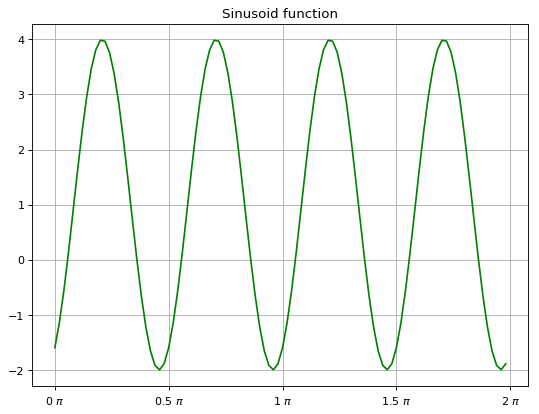

```python
################################################################################
# Sinusoid
# Author: stevenlee, tw.steven@gmail.com
# Date: 2017.05.19
################################################################################
import matplotlib.pyplot as plt
import matplotlib.ticker as tck
import numpy as np

fs = 100 # sample rate: How many point in 1 cycle
f = 4 # the frequency of the signal (Hz)

a = 3.0
b = 2*np.pi*f
h = np.pi/3
k = 1.0

x = np.arange(fs)
rad = [b * (i/fs)-h for i in np.arange(fs)]
tick = [2 * (i/fs) for i in np.arange(fs)] # tick is only for drawing x axis

y = a * np.sin(rad)+k

plt.figure(figsize=(8, 6), dpi=80)
ax = plt.gca()
ax.cla()
ax.xaxis.set_major_formatter(tck.FormatStrFormatter('%g $\pi$'))
ax.xaxis.set_major_locator(tck.MultipleLocator(base=0.5))

plt.title('Sinusoid function')
plt.plot(tick, y, 'g-',label='Sinusoid')
plt.grid(True)
plt.show()
```

## Everthing come together, and make sense in a beautiful form

#### Euler Identity $e^{i\pi }+1=0$

By definition, $e= (1+\frac{1}{n})^n, n \to \infty$

$e^z= (1+\frac{1}{n})^{nz}$

Let $N =nz$, $\frac{1}{n} = \frac{z}{N}$, then, $e^z= (1+\frac{z}{N})^{N}$

Let $z = i\pi$, then $e^{i\pi}= (1+\frac{i\pi}{N})^{N}$

When $N\to \infty$, $(1+\frac{i\pi}{N})^{N} \to -1$

So, $ e^{i\pi}+1=0$, This is the **Euler's equation**. It contains $0,1,e,\pi,i$. The independently developed concepts finally come together to one equation.

[figure not shown]

By Sbyrnes321 - Own work, Public Domain, [Link](https://commons.wikimedia.org/w/index.php?curid=3997246)

**Euler's identity** is a special case of Euler's formula from complex analysis, which states that for any real number x,

$${\displaystyle e^{ix}=\cos x+i\sin x}$$

where the inputs of the trigonometric functions sine and cosine are given in radians. In particular, when x = π, or one half-turn (180°) around a circle:

$${\displaystyle e^{i\pi }=\cos \pi +i\sin \pi .}$$

Since $\cos \pi =-1$, and $\sin \pi =0,$ it follows that ${\displaystyle e^{i\pi }=-1+0i,}$ which yields Euler's identity:

$${\displaystyle e^{i\pi }+1=0.}$$

[figure not shown]

By Original: Gunther Derivative work: Wereon - This file was derived from Euler's formula.png: , [CC BY-SA 3.0](http://creativecommons.org/licenses/by-sa/3.0/), [Link](https://commons.wikimedia.org/w/index.php?curid=821342)

#### To modify this doc, you may need to know:

Markdown language: https://github.com/adam-p/markdown-here/wiki/Markdown-Cheatsheet

LaTex math symbols: https://en.wikibooks.org/wiki/LaTeX/Mathematics

Python 3: https://docs.python.org/3/

HTML: https://www.w3schools.com/html/

Please feel free to mail me.